# Scala: an Introduction

[figure not shown]

*The left panel shows the functional features, the main one describes the type system, and the right the object oriented parts.*

# Overview

- Object-oriented programming paradigm
- Strong types, type inference
- Pattern matching
- Traits
- Higher-order functions
- Partial application
- Closures
- Tail recursion
- Runs on JVM
- Oriented towards concurrency, parallelism, and distributed programming
- Implicits

# Some useful tools and things

REPL:

- `sbt console` (from Scala Build Tools)
- `scala`

IDE:

- [Scala IDE](http://scala-ide.org/) (Eclipse)
- [IntelliJ IDEA](http://www.jetbrains.com/idea/features/scala.html)

Other:

- [Scala Build Tools](http://www.scala-sbt.org/) (although we still insist you use `make`)

Style guide (please use):

- [Scala Style Guide](http://docs.scala-lang.org/style/method-invocation.html)

#### Question:

**What is Scala’s Unified Object Model?**

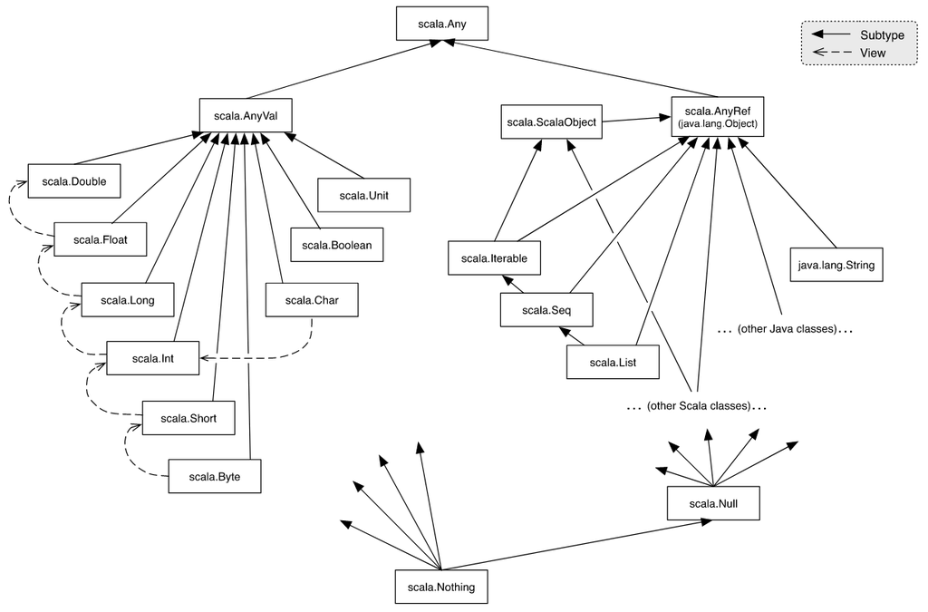

# Types

Basic types:

- `Boolean`
- `Char`, `Int`, `Long`, `Short`, `Byte`
- `Double`, `Float`
- `String`
- `Symbol`
- `Nothing`, `Null`, `Unit`
- `Any`, `AnyVal`, `AnyRef`

Functions:

- `Int => Int`
- `Int => Int => Int`
- `Int => Unit`

Tupples:

- `(Int, Int)`

#### Question:

**What is the reson for introducing type Unit?**

Unit:

```scala
val u: Unit = ()
```

Null:

```scala
val n: Null = null
val s: String = null
```

Aliasing:

```scala
type Identifier = Int
type Callback = Int => Int
type Vector3D = (Int, Int, Int)
```

Symbols:

```scala
val x = 'A
val y = 'B
```

# Selected operators

Arithmetic:

```scala
+ -
/ % *
```

Relational and logical:

```scala
< > <= >= == !=
|| && !
```

Bit-wise:

```scala
& | ^ ~
>> << >>>
```

Assignment:

```scala
= *= += -= /=
```

And more: [full list of operators](http://jim-mcbeath.blogspot.com/2008/12/scala-operator-cheat-sheet.html)

# Variables, values and function definitions

## Value declaration/definition

```scala
val x = 5
val s = "spaceship"
val y : Int = 0
```

Evaluated at definition. Cannot redefine.

```scala
x = x + 1
```

```
<console>:4: error: reassignment to val
```

## Variable declaration/definition

```scala
var x = 5
var s = "spaceship"
```

Evaluated at definition. Can redefine.

```scala
x = x + 1
s = "whoosh"
```

Default value of variable:

```scala
var x: Int = _
var y: Boolean = _
var s: String = _
var z: Any = _
```

## Function declaration/definition

```scala
def f = 1
def g = 1 + f
def h = (x: Int) => 1 + x
def h: Int => Int = x => 1 + x
```

Evaluated on use (Every time). Can redefine.

Limits of type inference:

```scala
def h = x => 1 + x
```

```
<console>:7: error: missing parameter type
       def h = (x) => 1 + x
```

#### Question:

**When and why to use `val` , `var`, `def`?**

# Objects

Everything is an object:

```scala
5.toString()
```

Operators are instance methods:

```scala
val x, y = 2

x + y
x.+(y)
```

## Simplifying method calls

Removing parentheses from method calls:

```scala
val x = 2
x.toString()
x.toString      // <==
x toString
```

**Style guide**: arity 0, pure methods only (no side effects).

Infix notation:

```scala
val s = "something something spaceship"
s.split(" ")
s split(" ")
s split " "     // <==
```

**Style guide**: arity 1, pure methods only (no side effects). Use especially if the argument is a function.

# Code blocks

Definition:

```scala
{ /*...*/ }
```

A block returns the last evaluated value:

```scala
{ 2 + 2 }
{ val x = 2; x }
{ val x = 2; val y = 2; x + y }
{ println("x") }
```

Variable scope and blocks:

```scala
val x = { 2 + 2 }       // x → 4
val y = { x + 2 }       // y → 6

{ val xx = 8; xx }      // x → 8
xx                      // explosion

{ x; val x = 8 }        // explosion
```

# Methods, functions, and partial functions

## Methods

Method definition (in the current object).

```scala
def increment(x: Int): Int = {
  return x + 1
}

def increment(x: Int): Int = {
  x + 1
}

def increment(x: Int) = {
  x + 1
}

def increment(x: Int) {x + 1}       // → unit

def increment(x: Int) = x + 1
```

Method nesting:

```scala
def outer(x: Int) = {
  def inner(y: Int) = y + x
  inner(x)
}
```

Unit argument:

```scala
def f() = 5
def g() = ()
```

Parameter with default values:

```scala
def add(x: Int, y: Int = 1) = x + y

add(1, 1)
add(1)
```

Multiple parameter groups and partial application:

```scala
var debugLevel = 5
def debug(level: Int)(message: String) { if (level >= debugLevel) println(message) }

debug(5)("a thing is happening")

val warn = debug(0) _
val error = debug(10) _

warn("a meh thing is happening")
error("a bad thing is happening")
```

### Call-by-name and call-by-value arguments

```scala
var debugLevel = 5
def debug(level: Int)(message: => String) { if (level >= debugLevel) println(message) }

warn("a" + " meh " + "thing is happening")
```

## Functions

Function (lambda) definitions:

```scala
(x: Int) => x + 1
() => println("Hello World!")

val f1 = (x: Int) => x + 1
f1(5)

val f2 = () => println("Hello World!")
f2()
```

Functions are anonymous.

Functions are objects:

```scala
val f1 = (x: Int) => x + 1

f1.apply(1)
f1.toString
```

### Converting between functions and methods

Explicit method to function conversion:

```scala
def increment(x: Int) = {x + 1}
val f = increment _             // η-conversion aka eta-conversion aka magic

val fs = "s".toString _
fs()
```

Automatic conversion:

```scala
def increment(x: Int) = {x + 1}

increment.apply(1)
increment.toString

val x = increment
x(1)
x.apply(1)
x.toString()
```

**Watch out when converting arrity 0 methods.**

### Function composition

```scala
val f = (x: Int) => x * x
val g = (x: Int) => x + 1

f(g(1))                     // (x + 1) * (x + 1) = 4
(f compose g)(1)            // (x + 1) * (x + 1) = 4

g(f(1))                     // (x * x) + 1 = 2
(f andThen g)(1)            // (x * x) + 1 = 2
```

### Partial application:

```scala
val sum = (a: Int, b: Int, c: Int) => a + b + c

val f1 = sum(1, 2, _: Int)
val f2 = sum(1, _: Int, _: Int)

f1(1)
f2(1, 1)
```

## Partial functions

```scala
val typeOf: Any => String = {
  case x: Int => "Int"
  case x: Double => "Double"
}

typeOf(1)
typeOf(1.0)
typeOf("spaceship")
```

```
scala.MatchError: spaceship (of class java.lang.String)
  at $anonfun$1.apply(<console>:7)
  at $anonfun$1.apply(<console>:7)
  ... 33 elided
```

#### Question:

**What are first-order functions?**  
**What are higher-order functions?**

### Higher-order and first-class functions

**First class functions** can be treated as values: assigned to variables, passed by arguments.

```scala
val a = (x: Int) => x + 1
val b = a
```

**Higher order function** can accept functions as arguments and/or return functions.

```scala
val f = (x: Int) => (y: Int) => x + y
val g = (x: Int) => { val z = x + 1; (y: Int) => z + y }
val h = (fun: Int => Int) => fun(1)
```

# Classes

## Definition

Minimal definition:

```scala
class Enterprise() {}
```

Default constructor (creates fields, executes code):

```scala
class Enterprise() {                        // primary constructor
  val version = "NCC-1701"
  val captain = "Kirk, J. T."

  val maxShields = 100
  var shieldDmg = 0

  def shieldLvl() = {maxShields - shieldDmg}

  println("Split all the infinitives!")
}
```

Creating objects:

```scala
val enterprise = new Enterprise()
```

## Field visibility

- `private` - private (visible to class)
- `private[package]` - private (visible to package)
- `private[this]` - private (visible to instance)
- `protected` - protected (visible to class and subclasses)
- `protected[package]` - protected (visible to package)
- `protected[this]` - protected (visible to instance)
- `public`

Default visibility is `public`.

## `private` vs `private[this]`

Access in any instance of the class with `private`

```scala
class Spaceship {
  private val name = "USS Enterprise"

  def compare (e: Spaceship): Boolean = e.name == this.name
}
```

Access only within instance:

```scala
class Spaceship {
  private[this] val name = "USS Enterprise"
  def getName() = name

  def compare (e: Spaceship): Boolean = e.getName() == this.name
}
```

## Constructor Arguments

```scala
class Enterprise(ver: String, capt: String) {
  val version = ver
  val captain = capt

  val maxShields = 100
  var shieldDmg = 0

  def shieldLvl() = {maxShields - shieldDmg}
}

val enterprise = new Enterprise("NCC-1701", "Kirk, J. T.")
enterprise.shieldDmg = 10
enterprise.shieldLvl()
enterprise.shieldLvl
```

## Argumentless methods

```scala
class Enterprise(ver: String, capt: String) {
  def version = ver
  def captain = capt

  val maxShields = 100
  var shieldDmg = 0

  def shieldLvl = {maxShields - shieldDmg}
}

val enterprise = new Enterprise("NCC-1701", "Kirk, J. T.")
enterprise.shieldDmg = 10
enterprise.shieldLvl
```

## Additional constructors

```scala
class Enterprise(ver: String, capt: String) {
  def this() = {
    this("NCC-1701", "Kirk, J. T.")        // First expression in method
  }
}
```

## Inheritence and overloading

```scala
abstract class Constitution() {     // extends AnyRef
  def shipClass = "Constitution"    // or val
  def shipName = {}
}

class Enterprise(ver: String, capt: String) extends Constitution {
  override def shipName = "Enterprise"
}
```

## Variable overloading:

```scala
abstract class Constitution() { // extends AnyRef
  var shipClass = "Constitution"
  def shipName = {}
}

class Enterprise(ver: String, capt: String) extends Constitution {
  override var shipClass = "Enterprise"
}
```

```
<console>:9: error: overriding variable shipClass in class Constitution of type java.lang.String;
variable shipClass cannot override a mutable variable
           override var shipClass = "Enterprise"
                        ^
```

## Multiple inheritance though traits

```scala
trait WarpSpeedCapability {
  var currentSpeed = 0
  def setCruisingSpeed = { currentSpeed = 2 }
  def setMaximumWarp = { currentSpeed = 9 }
}

class Enterprise(ver: String, capt: String) extends Constitution with WarpSpeedCapability {
  override def shipName = "Enterprise"
}
```

Solving conflicts:

```scala
trait AuxiliaryCraft {
  val awayTeamType = "shuttlecraft"
  def sendAwayTeam = {
    // ...
  }
}

trait Transporter {
  val awayTeamType = "transporter"
  def sendAwayTeam = {
    // ...
  }
}

class Enterprise(ver: String, capt: String) extends AuxiliaryCraft with Transporter {
  override def awayTeamType = "transporter or shuttlecraft"
  override def sendAwayTeam = {
    // ...
  }
}
```

Unreconcileable conflict:

```scala
trait AuxiliaryCraft {
  var isAwayTeamSent = false
  def sendAwayTeam = {
    // ...
  }
}

trait Transporter {
  var isAwayTeamSent = false
  def sendAwayTeam = {
    // ...
  }
}

class Enterprise(ver: String, capt: String, maxShld: Int) extends AuxiliaryCraft with Transporter {
  override def sendAwayTeam = {
    // ...
  }
}
```

```
<console>:9: error: class Enterprise inherits conflicting members:
  variable isAwayTeamSent in class AuxiliaryCraft$class of type Boolean  and
  variable isAwayTeamSent in class Transporter$class of type Boolean
(Note: this can be resolved by declaring an override in class Enterprise.);
 other members with override errors are: isAwayTeamSent_=
```

#### Question:

**What restrictions are placed on method identifiers in Scala?**

## Operator overloading

```scala
class C {
  def < (that: Any): Boolean = {
    // ...
  }
}
```

# Static objects

Static object definition (*singleton*):

```scala
object universe {
  val age: Long = 45L
  def getBlackHoles() = {
    // ...
  }
}
```

Scala does not allow creating static elements outside of static objects.

Companion object (*pattern*):

```scala
class Shipyard {
  def makeShip = ???
}

object Shipyard {
  def makeShipyard = ???
  def getAllShipyards = ???
}
```

#### Question:

**When are static objects created?**

Defining `main` functions:

```scala
object Something {
  def main(args: Array[String]) {
    // Code goes here.
  }
}
```

```scala
object Something extends App {
  // Code goes here.
}
```

## Generics

```scala
class RefCell[T] {
  private var obj: T = _
  def get: T = { obj }
  def set(value: T) = { obj = value }
}

val s = new RefCell[String]
s set "HelloWorld"
s get

val x = new RefCell[Int]
x set 5
x get
```

# Collections

*Immutable*: * tuples * lists * sets * maps * strings

*Mutable*:

- tables
- sets
- lists
- queues
- stacks
- string builders

## Immutable

### Tupples

```scala
val pair = ("alpha", "beta")
val triple = ("alpha", "beta", "gamma")

val x = pair _1
val y = pair _2

val (x,y) = pair

val riap = pair swap

val pair = "alpha" -> "beta"
```

### Lists

```scala
val c = List(1, 2, 3, 4)
val c = 1 :: 2 :: 3 :: 4 :: Nil
val c = List(1, 2) ::: List(3, 4)

c(0)

c head
c tail
c last
c isEmpty
c length

c reverse
c iterator

c slice (0, 2)
```

### Sets

```scala
val s = Set(1, 2, 3, 4, 4)

s(1)
s contains 1

s - 1
s + 5
s + (6,7)
s empty

val a = Set(1, 2, 3, 4)
val b = Set(3, 4, 5, 6)

a union b       // union
a | b           // union
a ++ b          // union

a subsetOf b

a intersect b   // intersection
a & b           // intersection

a diff b        // difference
a &~ b          // difference
a -- b          // difference
```

### Ranges

```scala
val r = Range(0, 10)

r(0)

val r = 1.to(10)
val r = 1.until(10)

val r = 1 to 10
val r = 1 until 10

r reverse
r iterator
```

### Maps

```scala
val m = Map("a" -> 1, "b" -> 2)
val m = Map(("a", 1), ("b", 2))

m("a")
m get "a"

m get "x"
m getOrElse ("x", -1)

m contains "a"

m + ("c" -> 3)
m + ("c" -> 3, "d" -> 4)

m ++ Map("c" -> 3, "d" -> 4)

m - "a"
m - ("a", "b")

m -- Map("c" -> 3, "d" -> 4)

m keys
m values
```

## Mutable

### Tables

```scala
val arr = new Array[String](3)

arr(0) = "ala"
arr(1) = "ma"
arr(2) = "kota"

val arr = Array("ala", "ma", "kota")

val cube = ofDim[Int](3,3)
cube(0,0) = 1
```

### Mutable versions of immutable collections

```scala
import scala.collection.mutable.LinkedList
import scala.collection.mutable.Set
import scala.collection.mutable.Map
import scala.collection.mutable.StringBuilder

val s : StringBuilder = new StringBuilder()

s append "a"
s ++= "b"

println(s.mkString)
```

## Generic collections

```scala
val ls : List[String] = "a" :: "b" :: "c" :: Nil
```

Covariance: *If A is a subtype of B then T[A] is a subtype of T[B].*

```scala
class Animal {}
class Dog extends Animal {}

val animals : List[Animal] = new Dog() :: new Dog() :: Nil
```

## Folds

### Fold function

```scala
def fold[A1 >: A](z: A1)(op: (A1, A1) => A1): A1

val l = List(1, 1, 1 ,1 ,1)
l.fold(0)((acc: Int, elem: Int) => acc + elem)

val ll = List(List(1, 1, 1), List(2, 2, 2))
ll.fold(List[Int]())((acc: List[Int], elem: List[Int]) => acc ::: elem)
```

Specified folding order:

```scala
def foldLeft[B](z: B)(op: (B, A) => B): B
def foldRight[B](z: B)(f: (A, B) => B): B

val l = List(1, 2, 3 ,4 ,5)
l.foldLeft(0)((acc: Int, elem: Int) => {println(acc+"+"+elem); acc + elem})
l.foldRight(0)((elem: Int, acc: Int) => {println(acc+"+"+elem); acc + elem})

l.foldLeft(List[Int]())((acc: List[Int], elem: Int) => elem :: acc)
l.foldRight(List[Int]())((elem: Int, acc: List[Int]) => elem :: acc)
```

### Reduce

```scala
val l = List(1, 2, 3 ,4 ,5)
l reduce { (acc, elem) => acc + elem }
l reduceLeft { (acc, elem) => acc + elem }
l reduceRight { (elem, acc) => acc + elem }
```

### Map

```scala
val l = List(1, 2, 3 ,4 ,5)
l map { x => x + 1 }
l map { x => x.toString }
```

### Flat map (bind)

```scala
val l = List(0, 1, 2, 3 ,4 ,5)
l flatMap { x => if (x == 0) List(x) else List(-x, x) }
l flatMap { x => if (x % 2 == 0) List(x) else List() }
```

### Filter

```scala
val l = List(1, 2, 3, 4, 5)
val even = l filter { x => (x % 2) == 0 }
val odd = l filterNot { x => x % 2 == 0 }
```

### Partition

```scala
val l = List(1, 2, 3, 4, 5)
val (even, odd) = l partition { x => x % 2 == 0 }
```

### Group

```scala
val l = List(1, 2, 3, 4, 5, 1, 2)
l groupBy { x => x % 2 }
l groupBy { x => x }
("to boldly go where no man has gone before" split " ") groupBy { x => x.charAt(0) }
```

# Control structures

## Conditional blocks

```scala
if (x > 0)
  z = x
else
  z = -x
```

## While Loops

```scala
while (x > 0)
  x -= 1

while (x > 0) {
  x -= 1
  println(x)
}
```

## For comprehensions

For loops:

```scala
l = List(1, 2, 3, 4, 5, 6, 7, 8, 9, 10)
for (i <- l)
  println(i)

for (i <- 1 to 10)
  println(i)

for (i <- 1 until 10)
  println(i)

for (i <- 1 to 10; j <- 1 to 10)
  println(i, j)
```

Loops with filters:

```scala
for (i <- 1 until 10 if i % 2 == 0)
  println(i)

for (i <- 1 until 10 if i % 2 == 0; if i % 3 == 0)
  println(i)
```

Lazy loop execution:

```scala
val result = for (i <- 1 to 10 if i % 2 == 0) yield i
result(3)
```

## Pattern matching

Matching by value:

```scala
def f(x: Any) = {
  x match {
    case "1" => 1
    case "a" | "A" => 10
    case "b" | "B" => 11
    case _ => -1
  }
}
```

Matching by type:

```scala
def f(x: Any) = {
  x match {
    case i: Int => i
    case s: String => {
      val lcase = s toLowerCase
      val ch = (lcase toCharArray) apply 0
      ch - 96
    }
    case _ => -1
  }
}
```

Matching collections:

```scala
def sum (l: Any, r: Int = 0) = {
  l match {
    case Nil => r
    case x :: tail => sum(tail, r + x)
  }
}
```

```scala
def fuzzyLength (l: Any) = {
  l match {
    case Nil => "empty"
    case _ :: Nil => "one"
    case _ :: _ :: Nil => "two"
    case _ :: _ :: tail => "more than two"
    case _ => "probably not a list"
  }
}
```

Conditional matching:

```scala
def grade(avg: Double) : String = {
  avg match {
    case x if x >= 90.0 => "A"
    case x if x >= 85.0 => "A-"
    case x if x >= 80.0 => "B+"
    case x if x >= 75.0 => "B"
    case x if x >= 70.0 => "B-"
    case x if x >= 65.0 => "C"
    case x if x >= 55.0 => "D"
    case x if x >= 0.00 => "E"
    case _ => "Um... I mean... in a way, I'm impressed."
  }
}
```

Case classes:

```scala
abstract class BTreeNode
case class Leaf(v: Int) extends BTreeNode
case class ConcreteNode(l: Leaf, r: Leaf, v: Int) extends BTreeNode

def sum(node: BTreeNode): Int = {
  node match {
    case ConcreteNode(l, r, v) => v + sum(l) + sum(r)
    case Leaf(v) => v
  }
}
```

Option types:

```scala
def f(x: Option[String]) = {
  x match {
    case None => throw new Exception()
    case Some(s) => s.split(" ")
  }
}
```

# Packages

```scala
package pl.edu.put.Test

package pl {
  package edu {
    package put {
      package Test {
        // ...
      }
    }
  }
}

import scala.math._
```

# Placeholder

```scala
val pair = (2, 3)
val (x, _) = pair
```

```scala
1::2::3::Nil map (e => -e)
1::2::3::Nil map (-_)
```

# Concurrency

## Java concurrency

Threads:

```scala
val th = new Thread(new Runnable {
  def run() {
    println("new thread")
  }
})

th start
println("old thread")
th join
```

Example, function running in separate thread:

```scala
def start[T](expression: => T) = {
  val th = new Thread(new Runnable{ def run() { expression } })
  th.start; th
}

start((0 until 100) map {e => println(e * e)})
```

## Concurrency control

Concurrent sequence:

```scala
var seq = 0

class Incr extends Thread {
  override def run () {
    println(seq)
    seq = seq + 1
  }
}

(0 until 10) map ((_) => (new Incr).start)
```

Critical section synchronization:

```scala
var seq = 0

class Incr extends Thread {
  override def run () {
    (this getClass) synchronized {
      println(seq)
      seq = seq + 1
    }
  }
}

(0 until 10) map ((_) => (new Incr).start)
```

A **volatile** variable:

```scala
@volatile var seq = 0
```

Synchronization primitives from `java.util.concurrent._`:

```scala
import java.util.concurrent.atomic.AtomicInteger
val aint = new AtomicInteger(0)
aint set 1
aint get

import java.util.concurrent.locks.ReentrantReadWriteLock
val l = new ReentrantReadWriteLock

val rl = l readLock
val wl = l writeLock

rl lock
rl unlock

ExecutorService
ForkJoinPool
```

Thread pool:

```scala
import java.util.concurrent.Executors

val cores = Runtime.getRuntime.availableProcessors
val pool = Executors.newFixedThreadPool(cores)

def toRunnable[T] (expression: => T) = { new Runnable{ def run() { expression } } }

pool.execute{ toRunnable { Thread sleep 1000; println("Hello") } }
pool.execute{ toRunnable { Thread sleep 10;   println("World") } }

pool.shutdown
```

Thread pool with results and Java-Scala conversion.

```scala
def toCallable[T] (expression: => T) = {
    new java.util.concurrent.Callable[T]{ def call() = { expression } }
}
val tasks = ((0 until 100) toList) map (e => toCallable {e * e})

import scala.collection.JavaConversions._
val jTasks = asJavaCollection(tasks)

val jResult = pool.invokeAll( jTasks )
val result = (asScalaBuffer(jResult) toList) map (e => e.get)
```

## Embarassingly Parallel Problems

Parallel collections:

```scala
val list = List(0, 1, 2, 3, 4, 5, 6, 7, 8, 9).par

list foreach { e => println(e) }
(list.par) foreach { e => println(e) }
```

## Futures

```scala
import scala.concurrent.ExecutionContext.Implicits.global
import scala.concurrent.Future

val f: Future[List[Int]] = Future { ((0 until 100) toList) map (e => e * e) }
val f: Future[List[Int]] = Future { Thread sleep 1000; ((0 until 100) toList) map (e => e * e) }
```

Asynchronous reading from futures.

```scala
f onSuccess { case result => println("done!" + result.last) }
f onFailure { case exception => println("fail!" + exception) }
```

Synchronous reading from futures.

```scala
f value

import scala.concurrent.Await
import scala.concurrent.duration._

Await.result(f, 100 seconds)
Await.result(f, Duration.Inf)
```

Folding: `Future.reduce`, `Future.fold`.

Example of using Futures for concurrency:

```scala
val l = (0 until 100) toList
val f = (x:Int) => println(x)
l map { e => Future { f(e) } }

val f = (x:Int) => { println(x); x * x }
l map { e => Future { f(e) } } map { e => Await.result(e, Duration.Inf) }
```